# COMPSCIX 415.2 Homework 6

Kate Mellon

3/10/2018

#### Exercise 1

1.) The variables in the data set are outcome, smoker, and age.

```r
library(tidyverse)
library(mosaicData)
data(Whickham)
glimpse(Whickham)
```

```
## Observations: 1,314
## Variables: 3
## $ outcome <fct> Alive, Alive, Dead, Alive, Alive, Alive, Alive, Dead, ...
## $ smoker  <fct> Yes, Yes, Yes, No, No, Yes, Yes, No, No, No, No, Yes, ...
## $ age     <int> 23, 18, 71, 67, 64, 38, 45, 76, 28, 27, 28, 34, 20, 72...
```

2.) There are 1,314 observations and each one represents an individual who had participated in a survey from 20 years prior and the follow up outcome 20 years later on whether they are alive or dead, their age at the time of the original survey, and their smoking status at the time of the original survey.

3.) At a glance the visualization of smoking status vs. outcome shows that more people who reported not smoking were dead 20 years later than those who reported smoking, however the overrall number of observations for non-smokers was greater.

```r
library(mosaicData)
library(tidyverse)

(test <- Whickham %>% count(outcome, smoker))
```

```
## # A tibble: 4 x 3
##   outcome smoker     n
##   <fct>   <fct>  <int>
## 1 Alive   No       502
## 2 Alive   Yes      443
## 3 Dead    No       230
## 4 Dead    Yes      139
```

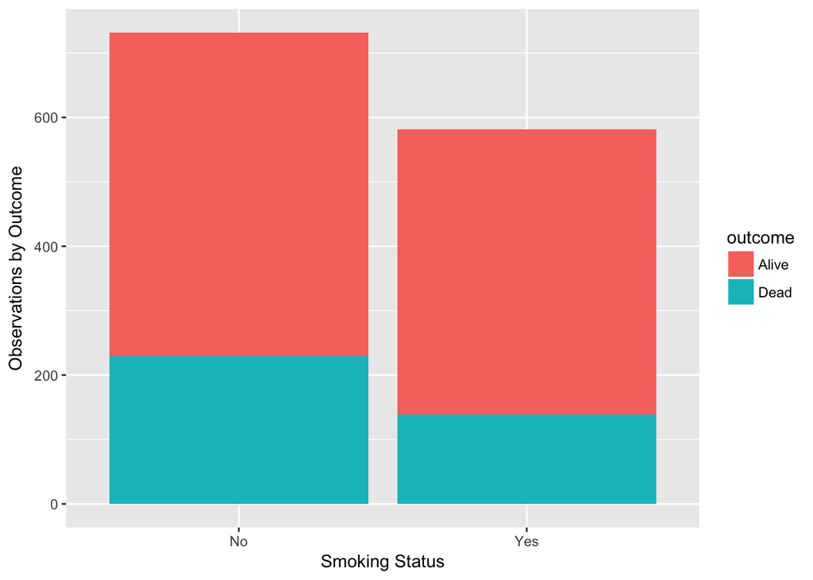

```r
ggplot(test, mapping=aes(x=smoker,y=n,fill=outcome)) +
  geom_col() +
  xlab("Smoking Status") +
  ylab("Observations by Outcome")
```

[figure not shown]

#### Exercise 2

1.)

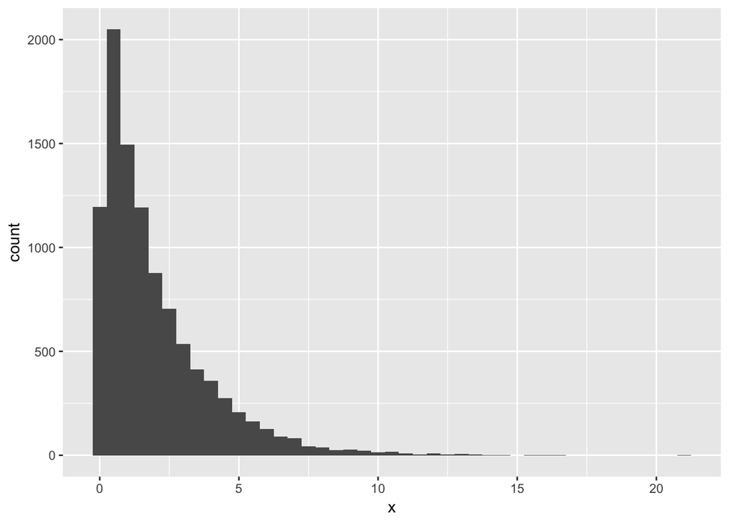

```r
library(tidyverse)
n <- 10000

gamma_samp <- tibble(x = rgamma(n, shape = 1, scale = 2))

ggplot(gamma_samp, mapping = aes(x)) +
  geom_histogram(binwidth=0.5)
```

```r
(mean_samp <- gamma_samp %>% .[['x']] %>% mean())
```

```
## [1] 1.966477
```

```r
(sd_samp <- gamma_samp %>% .[['x']] %>% sd())
```

```
## [1] 1.98396
```

3.)

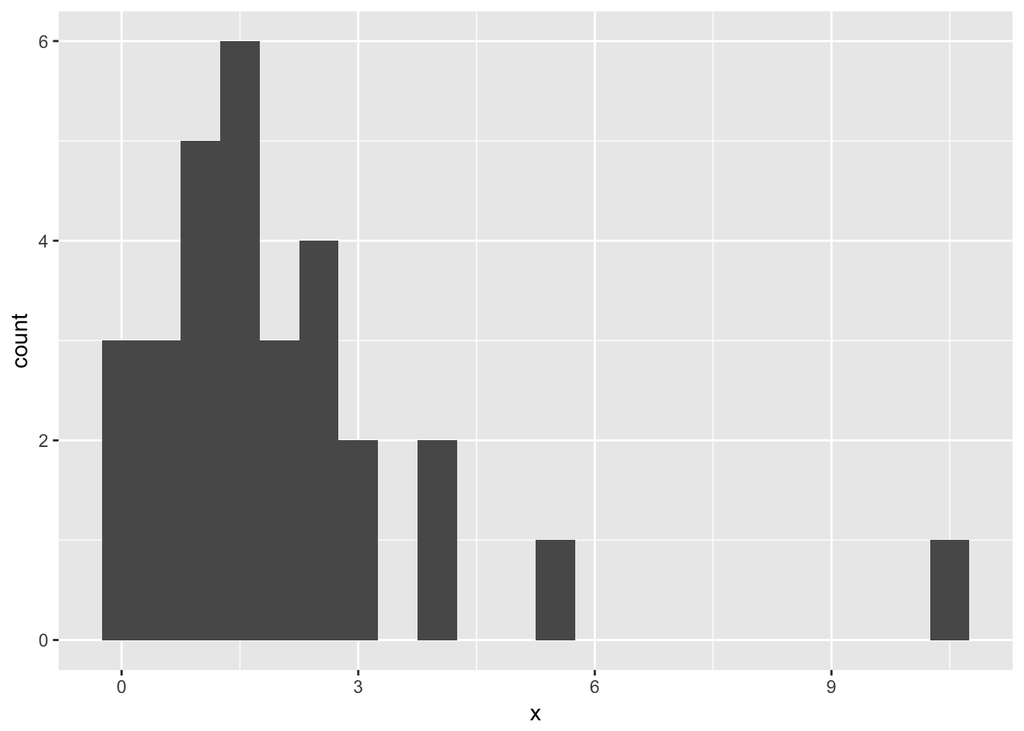

```r
gamma_samp <- tibble(x = rgamma(30, shape = 1, scale = 2))

ggplot(gamma_samp, mapping = aes(x)) +
  geom_histogram(binwidth = 0.5)
```

```r
(mean_samp <- gamma_samp %>% .[['x']] %>% mean())
```

```
## [1] 1.984526
```

```r
(sd_samp <- gamma_samp %>% .[['x']] %>% sd())
```

```
## [1] 2.081635
```

4.)

```r
mean_samp <- rep(NA, 10000)

for(i in 1:10000) {
g_samp <- rgamma(30, shape = 1, scale = 2)
mean_samp[i] <- mean(g_samp)
}

(mean_samp <- tibble(mean_samp))
```

```
## # A tibble: 10,000 x 1
##    mean_samp
##        <dbl>
##  1      1.58
##  2      2.33
##  3      1.80
##  4      1.74
##  5      1.47
##  6      1.66
##  7      2.03
##  8      2.16
##  9      1.59
## 10      2.52
## # ... with 9,990 more rows
```

5.)

```r
mean_samp <- rep(NA, 10000)

for(i in 1:10000) {
g_samp <- rgamma(30, shape = 1, scale = 2)
mean_samp[i] <- mean(g_samp)
}

(mean_samp <- tibble(mean_samp))
```

```
## # A tibble: 10,000 x 1
##    mean_samp
##        <dbl>
##  1      1.61
##  2      1.66
##  3      2.09
##  4      1.48
##  5      1.94
##  6      2.21
##  7      2.43
##  8      2.65
##  9      1.63
## 10      2.20
## # ... with 9,990 more rows
```

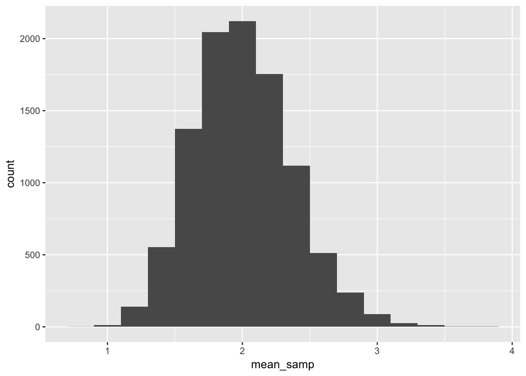

```r
ggplot(mean_samp, mapping = aes(mean_samp)) +
  geom_histogram(binwidth = 0.2)
```

6.)

```r
mean_samp <- rep(NA, 10000)

for(i in 1:10000) {
g_samp <- rgamma(30, shape = 1, scale = 2)
mean_samp[i] <- mean(g_samp)
}

mean_samp <- tibble(mean_samp)

(mean_sd <- mean_samp %>% summarize(mean=mean(mean_samp), sd=sd(mean_samp)))
```

```
## # A tibble: 1 x 2
##    mean    sd
##   <dbl> <dbl>
## 1  2.00 0.363
```

7.) The surprising part of exercise 6 is the standard deviation of ~.36 in comparison to the previously calculated standard deviation which was close to 2 when taking the sample mean wasn’t repeated 10k times.

8.) The results align well with the central limit theorem as increasing the sample size reduces the standard deviation from the sample means.

```r
mean_samp <- rep(NA, 10000)

for(i in 1:10000) {
g_samp <- rgamma(300, shape = 1, scale = 2)
mean_samp[i] <- mean(g_samp)
}

(mean_samp <- tibble(mean_samp))
```

```
## # A tibble: 10,000 x 1
##    mean_samp
##        <dbl>
##  1      1.88
##  2      2.02
##  3      1.87
##  4      1.88
##  5      1.97
##  6      2.08
##  7      2.02
##  8      1.90
##  9      2.01
## 10      2.04
## # ... with 9,990 more rows
```

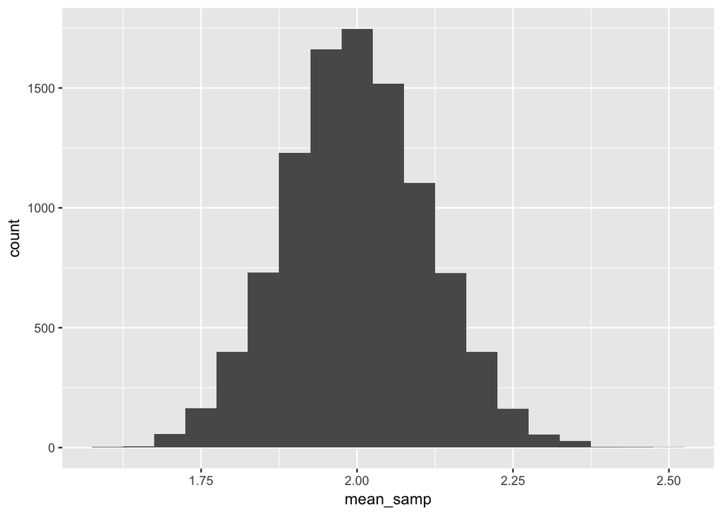

```r
ggplot(mean_samp, mapping = aes(mean_samp)) +
  geom_histogram(binwidth = 0.05)
```

```r
(mean_sd <- mean_samp %>% summarize(mean=mean(mean_samp), sd=sd(mean_samp)))
```

```
## # A tibble: 1 x 2
##    mean    sd
##   <dbl> <dbl>
## 1  2.00 0.114
```